# Rasch and two-parameter logistic item response models with latent regression

Daniel C. Furr

November 18, 2016

This case study uses **Stan** to fit the Rasch and two-parameter logistic (2PL) item response theory models, including a latent regression for person ability for both. The Rasch model is some times referred to as the one-parameter logistic model. Analysis is performed with **R**, making use of the **rstan** and **edstan** packages. **rstan** is the implementation of **Stan** for **R**, and **edstan** provides **Stan** models for item response theory and several convenience functions. The following **R** code loads the necessary packages and then sets some **rstan** options, which causes the compiled **Stan** model to be saved for future use and the MCMC chains to be executed in parallel.

```r
# Load R packages
library(rstan)
library(ggplot2)
library(edstan)
library(TAM)
rstan_options(auto_write = TRUE)
options(mc.cores = parallel::detectCores())
```

The case study uses **R** version 3.3.2, **rstan** version 2.12.1, **ggplot2** version 2.2.0, and **edstan** version 1.0.2. Also, the example data are from **TAM** version 1.995.0. Readers may wish to check the versions for their installed packages using the `packageVersion()` function.

# 1 Rasch model with latent regression

## 1.1 Overview of the model

The Rasch model (Rasch 1960) is an item response theory model for dichotomous items. The version presented includes a latent regression, in which the person abilities are regressed on person characteristics. However, the latent regression part of the model may be restricted to an intercept only, resulting in a regular Rasch model.

$$\mathrm{logit} [ \Pr(y_{ij} = 1 | \theta_j, \beta_i) ] =
\theta_j - \beta_i$$
$$\theta_j \sim \mathrm{N}(w_j' \lambda, \sigma^2)$$

Variables:

- $i = 1 \ldots I$ indexes items.
- $j = 1 \ldots J$ indexes persons.
- $y_{ij} \in \{ 0, 1 \}$ is the response of person $j$ to item $i$.
- $w_{j}$ is the vector of covariates for person $j$, the first element of which *must* equal one for a model intercept. $w_{j}$ may be assembled into a $J$-by-$K$ covariate matrix $W$, where $K$ is number of elements in $w_j$.

Parameters:

- $\beta_i$ is the difficulty for item $i$.
- $\theta_j$ is the ability for person $j$.
- $\lambda$ is the vector of latent regression parameters of length $K$.
- $\sigma^2$ is the variance for the ability distribution.

Constraints:

- The last item difficulty is constrained to be the negative sum of the other difficulties, $\beta_I = -\sum_{i}^{(I-1)} \beta_i$, resulting in the average item difficulty being zero.

## 1.2 **Stan** code for a simple Rasch model

```r
# Print the simple Rasch model from the edstan package
simple_rasch_file <- system.file("extdata/rasch_simple.stan",
                                 package = "edstan")
cat(readLines(simple_rasch_file), sep = "\n")
```

```
data {
  int<lower=1> I;               // # questions
  int<lower=1> J;               // # persons
  int<lower=1> N;               // # observations
  int<lower=1, upper=I> ii[N];  // question for n
  int<lower=1, upper=J> jj[N];  // person for n
  int<lower=0, upper=1> y[N];   // correctness for n
}
parameters {
  vector[I-1] beta_free;
  vector[J] theta;
  real<lower=1> sigma;
  real lambda;
}
transformed parameters {
  vector[I] beta;
  beta[1:(I-1)] = beta_free;
  beta[I] = -1*sum(beta_free);
}
model {
  beta_free ~ normal(0, 3);
  lambda ~ student_t(1, 0, 1);
  theta ~ normal(lambda, sigma);
  sigma ~ exponential(.1);
  y ~ bernoulli_logit(theta[jj] - beta[ii]);
}
```

Data are fed into the model in vector form. That is, `y` is a long vector of scored item responses, and `ii` and `jj` indicate with which item and person each element in `y` is associated. These three vectors are of length `N`, which is either equal to `I` times `J` or less if there are missing responses.

The model block contains the priors and the likelihood. Priors are placed on `beta_free` rather than on `beta`, as the prior does not apply to the constrained parameter. The likelihood (`y ~ ...`) uses vectorization by indexing `theta` and `beta` with `jj` and `ii`, which is more efficient than a loop.

## 1.3 **Stan** code for the Rasch model with latent regression

The Rasch model with latent regression will be discussed in relation to the simpler model, and both models are equivalent when the latent regression is restricted to an intercept only. The model with latent regression, which is featured in **edstan**, is printed below. It is more complicated than is typically necessary for a **Stan** model because it is written to apply sensible priors automatically for parameters associated with arbitrarily scaled covariates.

```r
# Print the latent regression Rasch model from the edstan package
rasch_latreg_file <- system.file("extdata/rasch_latent_reg.stan",
                                 package = "edstan")
cat(readLines(rasch_latreg_file), sep = "\n")
```

```
data {
  int<lower=1> I;               // # questions
  int<lower=1> J;               // # persons
  int<lower=1> N;               // # observations
  int<lower=1, upper=I> ii[N];  // question for n
  int<lower=1, upper=J> jj[N];  // person for n
  int<lower=0, upper=1> y[N];   // correctness for n
  int<lower=1> K;               // # person covariates
  matrix[J,K] W;                // person covariate matrix
}
transformed data {
  vector[K] center;              // values used to center covariates
  vector[K] spread;              // values used to scale covariates
  matrix[J,K] W_adj;             // centered and scaled covariates
  {
    real min_w;
    real max_w;
    int minmax_count;
    for(j in 1:J) W_adj[j,1] = 1;         // first column / intercept
    for(k in 2:K) {                       // remaining columns
      min_w = min(W[1:J, k]);
      max_w = max(W[1:J, k]);
      minmax_count = 0;
      for(j in 1:J) {
        minmax_count = minmax_count + W[j,k] == min_w || W[j,k] == max_w;
      }
      if(minmax_count == J) {             // if column takes only 2 values
        center[k] = mean(W[1:J, k]);
        spread[k] = (max_w - min_w);
      } else {                            // if column takes > 2 values
        center[k] = mean(W[1:J, k]);
        spread[k] = sd(W[1:J, k]) * 2;
      }
      for(j in 1:J) W_adj[j,k] = (W[j,k] - center[k]) / spread[k];
    }
  }
}
parameters {
  vector[I-1] beta_free;
  vector[J] theta;
  real<lower=0> sigma;
  vector[K] lambda_adj;
}
transformed parameters {
  vector[I] beta;
  beta[1:(I-1)] = beta_free;
  beta[I] = -1*sum(beta_free);
}
model {
  beta_free ~ normal(0, 3);
  theta ~ normal(W_adj*lambda_adj, sigma);
  lambda_adj ~ student_t(1, 0, 1);
  sigma ~ exponential(.1);
  y ~ bernoulli_logit(theta[jj] - beta[ii]);
}
generated quantities {
  vector[K] lambda;
  lambda[2:K] = lambda_adj[2:K] ./ spread[2:K];
  lambda[1] = W_adj[1, 1:K]*lambda_adj[1:K] - W[1, 2:K]*lambda[2:K];
}
```

The parameters, transformed parameters, and model blocks are similar to those for the simple model, except that `W_adj` and `lambda_adj` are used instead of `W` and `lambda`. Also, the prior for `theta` includes the regression prediction `W*lambda` as the mean. This approach is referred to as hierarchical centering and tends to be more efficient when there is a large amount of data. The alternative is a “decentered” approach in which the prior mean for `theta` would be set to zero, and then `W*lambda` would be added to `theta` in the likelihood statement. (The simple Rasch model may also be considered to use hierarchical centering given that the mean is included in the prior.)

Lastly, the generated quantities block is used to calculate what the regression coefficients and intercept would have been on the original covariate scales. For the coefficients this is determined simply by dividing the coefficients by the same value of `spread` used to scale the original covariates. The intercept given the original scale is also recovered with some algebra.

## 1.4 Simulation for parameter recovery

The **Stan** model is fit to a simulated dataset to evaluate it’s ability to recover the generating parameter values. The **R** code that follows simulates a dataset conforming to the model.

```r
# Set parameters for the simulated data
I <- 20
J <- 500
sigma <- .8
lambda <- c(-10*.05, .05, .5, -.025)
w_2 <- rnorm(J, 10, 5)
w_3 <- rbinom(J, 1, .5)
W <- cbind(1, w_2, w_3, w_2*w_3)
beta_free <- seq(from = -1, to = 1, length.out = I-1)

# Calculate or sample remaining variables and parameters
N <- I*J
ii <- rep(1:I, times = J)
jj <- rep(1:J, each = I)
beta <- c(beta_free, -1 * sum(beta_free))
rasch_theta <-  rnorm(J, W %*% matrix(lambda), sigma)
rasch_eta <- (rasch_theta[jj] - beta[ii])
rasch_y <- rbinom(N, size = 1, prob = boot::inv.logit(rasch_eta))

# Assemble the data list using an edstan function
sim_rasch_list <- irt_data(y = rasch_y, ii = ii, jj = jj,
                           covariates = as.data.frame(W),
                           formula = NULL)
```

The simulated data consists of 20 dichotomous items and 500 persons. The person covariate vectors $w_j$ include (1) a value of one for the model intercept, (2) a random draw from a normal distribution with mean of 10 and standard deviation of 5, (3) an indicator variable taking values of zero and one, and (4) an interaction between the two. These are chosen to represent a difficult case for assigning automatic priors for the latent regression coefficients. The generating coefficients $\lambda$ for the latent regression are -0.5, 0.05, 0.5, and -0.025. The generating unconstrained difficulties $\beta_1 \cdots \beta_{19}$ are equidistant values between -1 and 1, the constrained difficulty $\beta_{20}$ is equal to 0, and the abilities $\theta$ are random draws from a normal distribution with a mean generated from the latent regression and a standard deviation $\sigma = 0.8$.

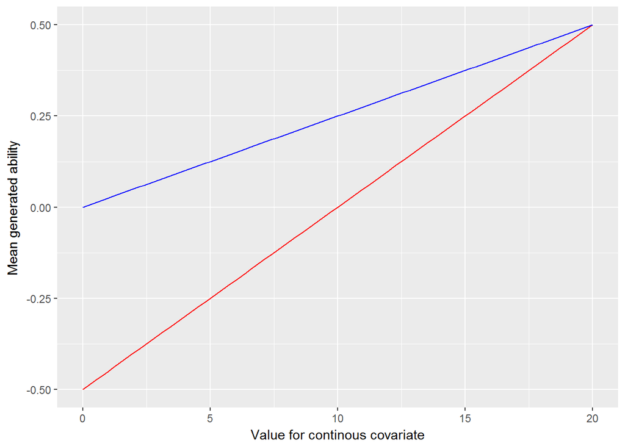

Mean of generated abilities as a function of the continuous covariate. A line is shown separately for the two groups identified by the binary variable.

```r
# Plot mean ability conditional on the covariates
f1 <- function(x) lambda[1] + x*lambda[2]
f2 <- function(x) lambda[1] + lambda[3] + x*(lambda[2] + lambda[4])
ggplot(data.frame(w2 = c(0, 20))) +
  aes(x = w2) +
  stat_function(fun = f1, color = "red") +
  stat_function(fun = f2, color = "blue") +
  ylab("Mean generated ability") +
  xlab("Value for continous covariate")
```

```r
# Fit model to simulated data using an edstan function
sim_rasch_fit <- irt_stan(sim_rasch_list, model = "rasch_latent_reg.stan",
                          chains = 4, iter = 1000)
```

The highest value for $\hat R$ was 1.008 for all parameters and the log posterior, suggesting that the chains have converged. The **Stan** model is evaluated in terms of its ability to recover the generating values of the parameters. The R code below prepares a plot in which the points indicate the difference between the posterior means and generating values for the parameters of main interest. This difference is referred to as discrepancy. The lines indicate the 95% poster intervals for the difference, defined as the 2.5th and 97.5th percentiles of the posterior draws. Ideally, (nearly) all the 95% intervals would include zero.

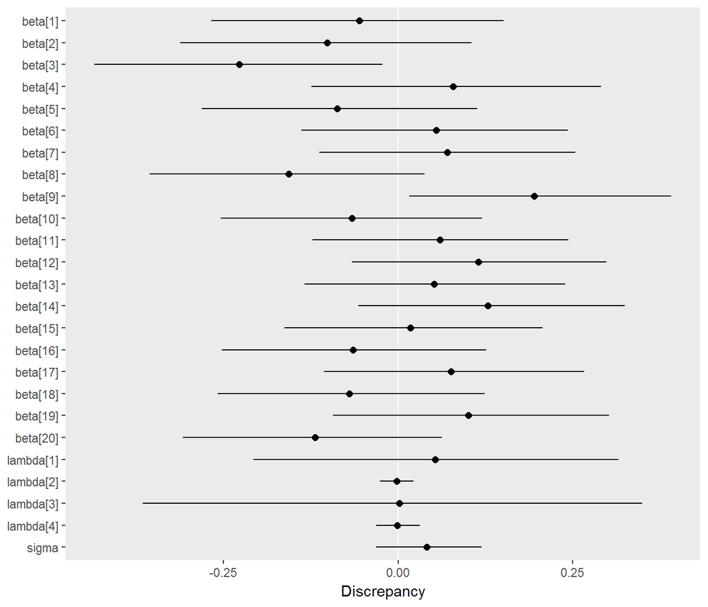

Discrepancies between estimated and generating parameters. Points indicate the difference between the posterior means and generating values for a parameter, and horizontal lines indicate 95% posterior intervals for the difference. Most of the discrepancies are about zero, indicating that **Stan** successfully recovers the true parameters.

```r
# Get estimated and generating values for wanted parameters
rasch_generating_values <- c(beta, lambda, sigma)
rasch_estimated_values <- summary(sim_rasch_fit,
                                  pars = c("beta", "lambda", "sigma"),
                                  probs = c(.025, .975))
rasch_estimated_values <- rasch_estimated_values[["summary"]]

# Make a data frame of the discrepancies
rasch_discrep <- data.frame(par = rownames(rasch_estimated_values),
                            mean = rasch_estimated_values[, "mean"],
                            p025 = rasch_estimated_values[, "2.5%"],
                            p975 = rasch_estimated_values[, "97.5%"],
                            gen = rasch_generating_values)
rasch_discrep$par <- with(rasch_discrep, factor(par, rev(par)))
rasch_discrep$lower <- with(rasch_discrep, p025 - gen)
rasch_discrep$middle <- with(rasch_discrep, mean - gen)
rasch_discrep$upper <- with(rasch_discrep, p975 - gen)

# Plot the discrepancies
ggplot(rasch_discrep) +
  aes(x = par, y = middle, ymin = lower, ymax = upper) +
  scale_x_discrete() +
  labs(y = "Discrepancy", x = NULL) +
  geom_abline(intercept = 0, slope = 0, color = "white") +
  geom_linerange() +
  geom_point(size = 2) +
  theme(panel.grid = element_blank()) +
  coord_flip()
```

# 2 Two-parameter logistic model with latent regression

## 2.1 Overview of the model

The two-parameter logistic model (2PL) (Swaminathan and Gifford 1985) is an item response theory model that includes parameters for both the difficulty and discrimination of dichotomous items. The version presented includes a latent regression. However, the latent regression part of the model may be restricted to an intercept only, resulting in a regular 2PL.

$$\mathrm{logit} [ \Pr(y_{ij} = 1 | \alpha_i, \beta_i, \theta_j) ] =
\alpha_i \theta_j - \beta_i$$
$$\theta_j \sim \mathrm{N}(w_j' \lambda, 1)$$

## 2.2 **Stan** code for the 2PL with latent regression

The **Stan** code for the 2PL is similar to that for the Rasch model except for the addition of the discrimination parameters.

```r
# Print the latent regression 2PL model from the edstan package
twopl_latreg_file <- system.file("extdata/2pl_latent_reg.stan",
                                 package = "edstan")
cat(readLines(twopl_latreg_file), sep = "\n")
```

```
data {
  int<lower=1> I;               // # questions
  int<lower=1> J;               // # persons
  int<lower=1> N;               // # observations
  int<lower=1, upper=I> ii[N];  // question for n
  int<lower=1, upper=J> jj[N];  // person for n
  int<lower=0, upper=1> y[N];   // correctness for n
  int<lower=1> K;               // # person covariates
  matrix[J,K] W;                // person covariate matrix
}
transformed data {
  vector[K] center;              // values used to center covariates
  vector[K] spread;              // values used to scale covariates
  matrix[J,K] W_adj;             // centered and scaled covariates
  {
    real min_w;
    real max_w;
    int minmax_count;
    for(j in 1:J) W_adj[j,1] = 1;         // first column / intercept
    for(k in 2:K) {                       // remaining columns
      min_w = min(W[1:J, k]);
      max_w = max(W[1:J, k]);
      minmax_count = 0;
      for(j in 1:J) {
        minmax_count = minmax_count + W[j,k] == min_w || W[j,k] == max_w;
      }
      if(minmax_count == J) {             // if column takes only 2 values
        center[k] = mean(W[1:J, k]);
        spread[k] = (max_w - min_w);
      } else {                            // if column takes > 2 values
        center[k] = mean(W[1:J, k]);
        spread[k] = sd(W[1:J, k]) * 2;
      }
      for(j in 1:J)
        W_adj[j,k] = (W[j,k] - center[k]) / spread[k];
    }
  }
}
parameters {
  vector<lower=0>[I] alpha;
  vector[I-1] beta_free;
  vector[J] theta;
  vector[K] lambda_adj;
}
transformed parameters {
  vector[I] beta;
  beta[1:(I-1)] = beta_free;
  beta[I] = -1*sum(beta_free);
}
model {
  alpha ~ lognormal(1, 1);
  beta_free ~ normal(0, 3);
  lambda_adj ~ student_t(3, 0, 1);
  theta ~ normal(W_adj*lambda_adj, 1);
  y ~ bernoulli_logit(alpha[ii].*theta[jj] - beta[ii]);
}
generated quantities {
  vector[K] lambda;
  lambda[2:K] = lambda_adj[2:K] ./ spread[2:K];
  lambda[1] = W_adj[1, 1:K]*lambda_adj[1:K] - W[1, 2:K]*lambda[2:K];
}
```

## 2.3 Simulation for parameter recovery

The **Stan** model is fit to a simulated dataset to evaluate it’s ability to recover the generating parameter values. The **R** code that follows simulates a dataset conforming to the model. The item difficulties and some other elements are borrowed from the Rasch model simulation.

```r
# Set alpha, and otherwise use parameters from the previous simulation
alpha <- rep(c(.8, 1, 1.2, 1.4),  length.out = I)

# Calculate or sample remaining variables and parameters where needed
twopl_theta <-  rnorm(J, W %*% matrix(lambda), 1)
twopl_eta <- alpha[ii]*twopl_theta[jj] - beta[ii]
twopl_y <- rbinom(N, size = 1, prob = boot::inv.logit(twopl_eta))

# Assemble the data list using an edstan function
sim_2pl_list <- irt_data(y = twopl_y, ii = ii, jj = jj,
                         covariates = as.data.frame(W),
                         formula = NULL)
```

The simulated dataset is next fit with **Stan** using `irt_stan()` from the **edstan** package.

```r
# Fit model to simulated data using an edstan function
sim_2pl_fit <- irt_stan(sim_2pl_list, model = "2pl_latent_reg.stan",
                        chains = 4, iter = 1000)
```

The highest value for $\hat R$ was 1.006 for all parameters and the log posterior. The **Stan** model is evaluated in terms of its ability to recover the generating values of the parameters. The R code below prepares a plot in which the points indicate the difference between the posterior means and generating values for the parameters of main interest. This difference is referred to as discrepancy. The lines indicate the 95% poster intervals for the difference, defined as the 2.5th and 97.5th percentiles of the posterior draws. Ideally, (nearly) all the 95% intervals would include zero.

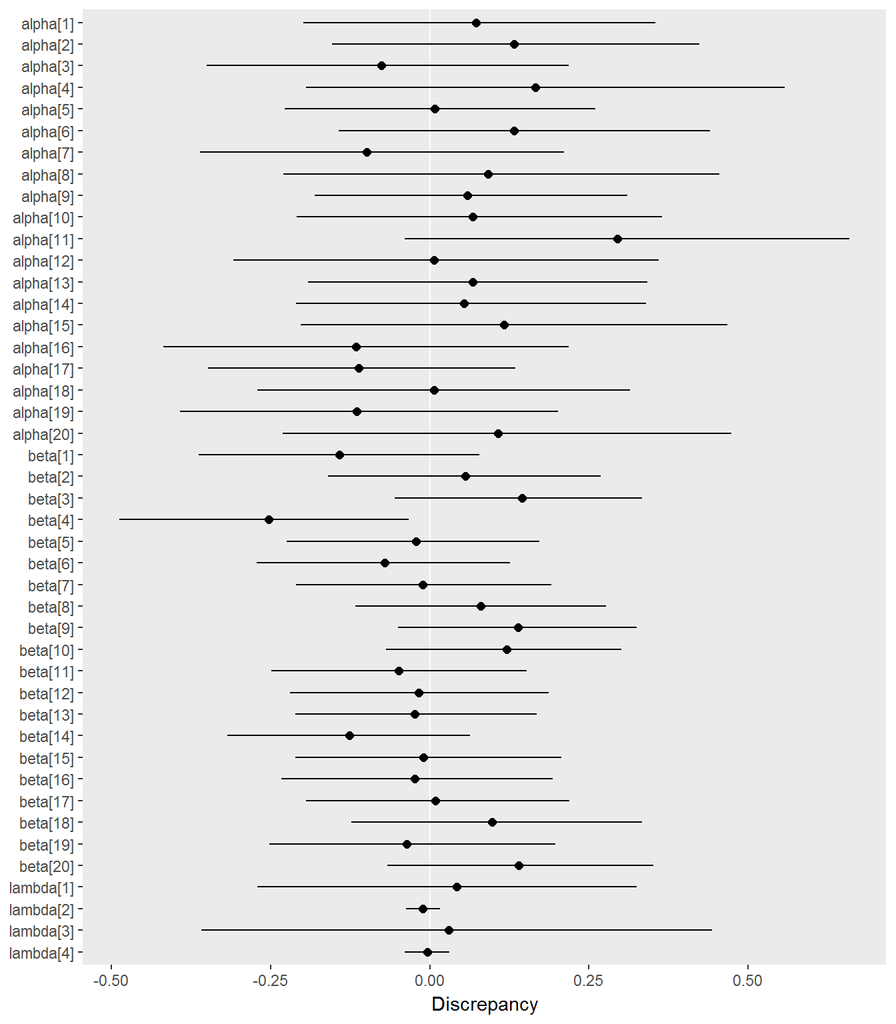

Discrepancies between estimated and generating parameters. Points indicate the difference between the posterior means and generating values for a parameter, and horizontal lines indicate 95% posterior intervals for the difference. Most of the discrepancies are about zero, indicating that **Stan** successfully recovers the true parameters.

```r
# Get estimated and generating values for wanted parameters
twopl_generating_values <- c(alpha, beta, lambda)
twopl_estimated_values <- summary(sim_2pl_fit,
                                  pars = c("alpha", "beta", "lambda"),
                                  probs = c(.025, .975))
twopl_estimated_values <- twopl_estimated_values[["summary"]]

# Make a data frame of the discrepancies
twopl_discrep <- data.frame(par = rownames(twopl_estimated_values),
                            mean = twopl_estimated_values[, "mean"],
                            p025 = twopl_estimated_values[, "2.5%"],
                            p975 = twopl_estimated_values[, "97.5%"],
                            gen = twopl_generating_values)
twopl_discrep$par <- with(twopl_discrep, factor(par, rev(par)))
twopl_discrep$lower <- with(twopl_discrep, p025 - gen)
twopl_discrep$middle <- with(twopl_discrep, mean - gen)
twopl_discrep$upper <- with(twopl_discrep, p975 - gen)

# Plot the discrepancies
ggplot(twopl_discrep) +
  aes(x = par, y = middle, ymin = lower, ymax = upper) +
  scale_x_discrete() +
  labs(y = "Discrepancy", x = NULL) +
  geom_abline(intercept = 0, slope = 0, color = "white") +
  geom_linerange() +
  geom_point(size = 2) +
  theme(panel.grid = element_blank()) +
  coord_flip()
```

# 3 Example application

## 3.1 Data

The example data are from the The First International Mathematics Study (Husen and others 1967; Postlethwaite 1967). The data include information about student gender and country (Australia or Japan). For convenience, only a subset of the full data are used.

```r
# Attach the example dataset. The TAM package is required.
data(data.fims.Aus.Jpn.scored, package = "TAM")

# Subset the full data
select <- floor(seq(from = 1, to = nrow(data.fims.Aus.Jpn.scored),
                    length.out = 500))
subsetted_df <- data.fims.Aus.Jpn.scored[select, ]
str(subsetted_df)
```

```
## 'data.frame':    500 obs. of  16 variables:
##  $ SEX    : int  1 1 2 2 1 1 2 2 2 1 ...
##  $ M1PTI1 : num  1 1 1 0 0 1 1 1 1 1 ...
##  $ M1PTI2 : num  0 0 0 0 0 1 1 1 1 1 ...
##  $ M1PTI3 : num  1 1 1 0 1 1 0 1 1 0 ...
##  $ M1PTI6 : num  1 0 0 1 0 0 0 1 1 0 ...
##  $ M1PTI7 : num  0 0 0 0 0 1 0 0 0 0 ...
##  $ M1PTI11: num  1 0 0 0 0 0 1 1 1 0 ...
##  $ M1PTI12: num  0 0 0 0 0 1 0 0 1 1 ...
##  $ M1PTI14: num  0 0 1 0 0 1 0 1 1 1 ...
##  $ M1PTI17: num  1 0 0 0 0 1 0 1 1 0 ...
##  $ M1PTI18: num  0 0 1 1 0 0 1 1 0 1 ...
##  $ M1PTI19: num  0 0 0 0 0 1 0 0 0 0 ...
##  $ M1PTI21: num  0 0 0 0 0 0 0 0 0 0 ...
##  $ M1PTI22: num  0 0 0 0 0 1 0 0 0 0 ...
##  $ M1PTI23: num  1 1 1 1 0 1 1 1 0 0 ...
##  $ country: int  1 1 1 1 1 1 1 1 1 1 ...
```

The dataset is next divided into an item response matrix and a matrix of student covariates.

```r
# Extract the response matrix
response_matrix <- as.matrix(subsetted_df[, grepl("^M1", names(subsetted_df))])
dim(response_matrix)
```

```
## [1] 500  14
```

```r
# Set up a data frame of person covariates
covariates <- data.frame(male = as.numeric(subsetted_df$SEX == 2),
                         japan = as.numeric(subsetted_df$country == 2))
table(covariates)
```

```
##     japan
## male   0   1
##    0 181  80
##    1 158  81
```

```r
# Assemble the data list using an edstan function
ex_list <- irt_data(response_matrix = response_matrix,
                    covariates = covariates,
                    formula = ~ male*japan)
```

## 3.2 Rasch model results

The Rasch model is fit to the data list.

```r
# Fit the Rasch model model using an edstan function
ex_rasch_fit <- irt_stan(ex_list, model = "rasch_latent_reg.stan",
                         chains = 4, iter = 300)
```

As discussed above, convergence of the chains is assessed for every parameter, and also the log posterior density, using $\hat{R}$.

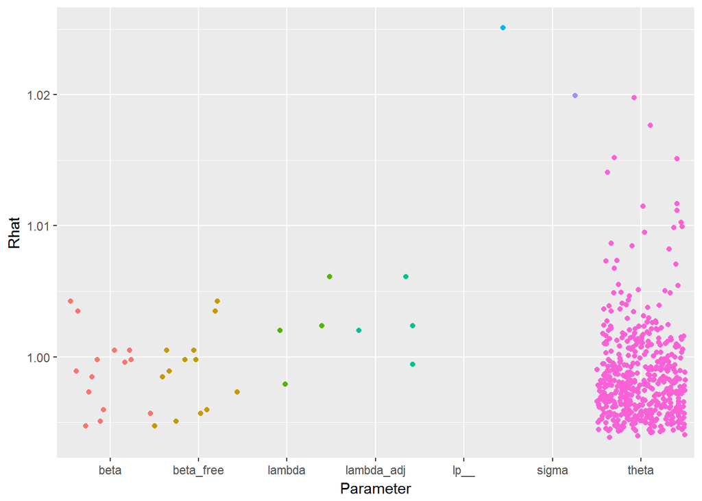

Convergence statistics ($\hat{R}$) by parameter for the example. All values should be less than 1.1 to infer convergence. Horizontal jitter is applied to the points.

```r
# Plot of convergence statistics using an edstan function
stan_columns_plot(ex_rasch_fit)
```

Next we view summaries of the parameter posteriors.

```r
# View table of parameter posteriors using an edstan function
print_irt_stan(ex_rasch_fit)
```

```
## Inference for Stan model: rasch_latent_reg.
## 4 chains, each with iter=300; warmup=150; thin=1;
## post-warmup draws per chain=150, total post-warmup draws=600.
##
##            mean se_mean   sd  2.5%   25%   50%   75% 97.5% n_eff Rhat
## beta[1]   -1.62    0.00 0.11 -1.82 -1.69 -1.61 -1.55 -1.40   600 1.00
## beta[2]   -1.44    0.00 0.12 -1.68 -1.51 -1.44 -1.36 -1.21   600 1.00
## beta[3]   -2.03    0.01 0.13 -2.30 -2.13 -2.03 -1.95 -1.78   600 1.00
## beta[4]   -0.44    0.00 0.09 -0.63 -0.49 -0.44 -0.38 -0.27   526 1.00
## beta[5]    1.85    0.00 0.12  1.62  1.76  1.85  1.92  2.10   600 1.00
## beta[6]   -1.58    0.00 0.11 -1.80 -1.66 -1.58 -1.51 -1.38   600 1.00
## beta[7]    0.83    0.00 0.10  0.64  0.75  0.82  0.90  1.04   600 1.00
## beta[8]    0.36    0.00 0.10  0.17  0.29  0.36  0.42  0.55   600 1.00
## beta[9]    1.06    0.00 0.11  0.86  0.99  1.05  1.13  1.28   600 1.00
## beta[10]  -0.49    0.00 0.10 -0.68 -0.56 -0.49 -0.43 -0.30   475 1.00
## beta[11]   1.59    0.00 0.12  1.37  1.52  1.59  1.67  1.82   600 0.99
## beta[12]   1.29    0.00 0.11  1.08  1.22  1.29  1.36  1.52   600 1.00
## beta[13]   1.75    0.00 0.12  1.53  1.67  1.75  1.83  1.99   600 1.00
## beta[14]  -1.14    0.00 0.10 -1.33 -1.21 -1.14 -1.07 -0.95   600 1.00
## lambda[1] -0.36    0.00 0.08 -0.52 -0.41 -0.36 -0.30 -0.21   479 1.00
## lambda[2]  0.08    0.01 0.12 -0.14  0.00  0.09  0.16  0.33   520 1.00
## lambda[3]  1.02    0.01 0.15  0.75  0.91  1.02  1.12  1.30   431 1.01
## lambda[4] -0.22    0.01 0.20 -0.59 -0.35 -0.23 -0.08  0.15   400 1.00
## sigma      0.89    0.00 0.05  0.80  0.86  0.89  0.93  0.99   206 1.02
##
## Samples were drawn using NUTS(diag_e) at Fri Nov 18 10:18:00 2016.
## For each parameter, n_eff is a crude measure of effective sample size,
## and Rhat is the potential scale reduction factor on split chains (at
## convergence, Rhat=1).
```

A Rasch model without the latent regression could be fit by changing the person covariate matrix to include only an intercept term. Shown below is how this may be done for the example data.

```r
# Fit the example data without latent regression
noreg_list <- ex_list
noreg_list$W <- matrix(1, nrow = ex_list$J, ncol = 1)
noreg_list$K <- 1
noreg_fit <- stan(file = "rasch_latent_reg.stan",
                  data = noreg_list, chains = 4, iter = 300)
```

## 3.3 Two parameter logistic model results

The 2PL is fit to the data list.

```r
# Fit the 2PL using an edstan function
ex_2pl_fit <- irt_stan(ex_list, model = "2pl_latent_reg.stan",
                       chains = 4, iter = 300)
```

As discussed above, convergence of the chains is assessed for every parameter, and also the log posterior density, using $\hat{R}$.

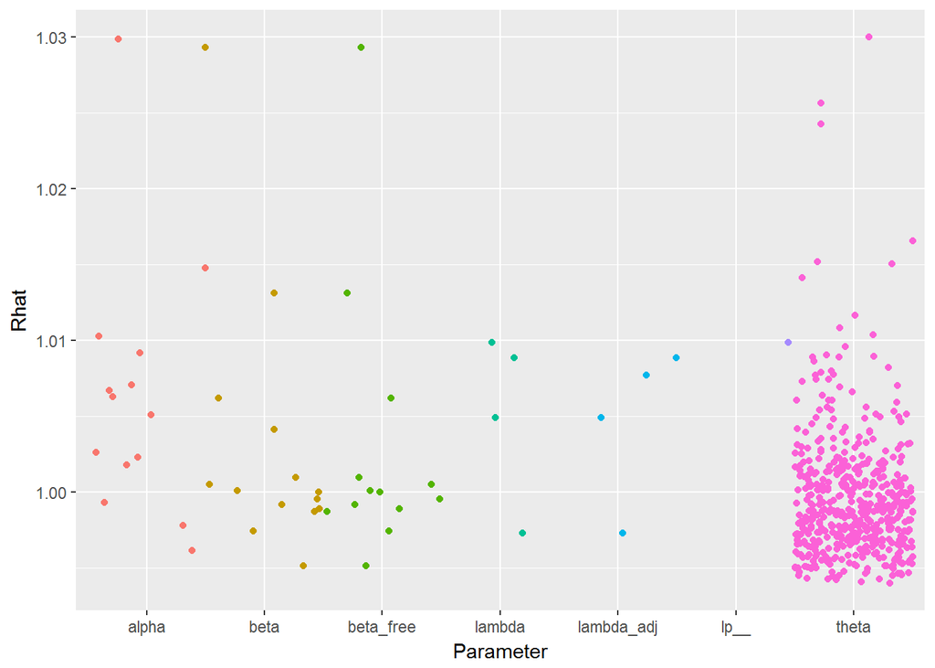

Convergence statistics ($\hat{R}$) by parameter for the example. All values should be less than 1.1 to infer convergence. Horizontal jitter is applied to the points.

```r
# Plot of convergence statistics using an edstan function
stan_columns_plot(ex_2pl_fit)
```

Next we view summaries of the parameter posteriors.

```r
# View table of parameter posteriors using an edstan function
print_irt_stan(ex_2pl_fit, ex_list)
```

```
## Inference for Stan model: 2pl_latent_reg.
## 4 chains, each with iter=300; warmup=150; thin=1;
## post-warmup draws per chain=150, total post-warmup draws=600.
##
##              mean se_mean   sd  2.5%   25%   50%   75% 97.5% n_eff Rhat
## Item 1: M1PTI1
##   alpha[1]   0.73    0.01 0.15  0.48  0.62  0.73  0.82  1.03   399 1.01
##   beta[1]   -1.56    0.01 0.14 -1.82 -1.65 -1.56 -1.46 -1.31   600 1.01
## Item 2: M1PTI2
##   alpha[2]   1.50    0.02 0.24  1.06  1.34  1.47  1.65  2.00   165 1.03
##   beta[2]   -1.81    0.01 0.18 -2.18 -1.93 -1.80 -1.68 -1.46   291 1.01
## Item 3: M1PTI3
##   alpha[3]   1.15    0.01 0.20  0.75  1.01  1.15  1.26  1.58   303 1.01
##   beta[3]   -2.24    0.01 0.19 -2.67 -2.35 -2.22 -2.10 -1.89   348 1.00
## Item 4: M1PTI6
##   alpha[4]   1.23    0.01 0.17  0.94  1.11  1.20  1.33  1.57   416 1.00
##   beta[4]   -0.54    0.01 0.11 -0.78 -0.61 -0.54 -0.46 -0.32   445 1.00
## Item 5: M1PTI7
##   alpha[5]   1.85    0.01 0.27  1.38  1.66  1.84  2.02  2.39   341 1.00
##   beta[5]    2.42    0.01 0.21  2.05  2.28  2.41  2.57  2.85   343 1.00
## Item 6: M1PTI11
##   alpha[6]   1.39    0.01 0.20  1.01  1.25  1.40  1.53  1.82   363 1.01
##   beta[6]   -1.92    0.01 0.17 -2.29 -2.03 -1.92 -1.81 -1.59   600 1.00
## Item 7: M1PTI12
##   alpha[7]   0.48    0.00 0.11  0.28  0.41  0.48  0.55  0.71   600 1.01
##   beta[7]    0.73    0.00 0.10  0.54  0.66  0.73  0.79  0.93   600 1.00
## Item 8: M1PTI14
##   alpha[8]   0.30    0.00 0.09  0.13  0.24  0.30  0.36  0.48   434 1.00
##   beta[8]    0.31    0.00 0.09  0.13  0.25  0.30  0.37  0.48   600 1.00
## Item 9: M1PTI17
##   alpha[9]   1.21    0.01 0.16  0.92  1.09  1.21  1.32  1.52   317 1.01
##   beta[9]    1.12    0.01 0.12  0.91  1.05  1.12  1.20  1.36   399 1.03
## Item 10: M1PTI18
##   alpha[10]  0.66    0.01 0.13  0.43  0.58  0.66  0.75  0.92   405 1.00
##   beta[10]  -0.47    0.00 0.10 -0.67 -0.53 -0.47 -0.40 -0.27   600 1.00
## Item 11: M1PTI19
##   alpha[11]  2.23    0.03 0.37  1.59  1.97  2.21  2.48  3.02   165 1.01
##   beta[11]   2.33    0.02 0.26  1.89  2.14  2.31  2.50  2.89   243 1.00
## Item 12: M1PTI21
##   alpha[12]  0.17    0.00 0.07  0.06  0.12  0.17  0.22  0.33   600 1.00
##   beta[12]   1.12    0.00 0.10  0.91  1.04  1.12  1.19  1.33   600 1.00
## Item 13: M1PTI22
##   alpha[13]  1.28    0.01 0.18  0.92  1.16  1.28  1.39  1.66   322 1.00
##   beta[13]   1.92    0.01 0.16  1.60  1.82  1.92  2.03  2.23   274 1.00
## Item 14: M1PTI23
##   alpha[14]  1.41    0.01 0.19  1.08  1.27  1.40  1.52  1.80   237 1.01
##   beta[14]  -1.41    0.01 0.15 -1.70 -1.51 -1.41 -1.31 -1.12   336 1.00
## Ability distribution
##   lambda[1] -0.43    0.00 0.09 -0.60 -0.49 -0.43 -0.37 -0.26   364 1.01
##   lambda[2]  0.06    0.01 0.12 -0.17 -0.02  0.06  0.14  0.31   494 1.00
##   lambda[3]  1.18    0.01 0.16  0.86  1.07  1.17  1.28  1.50   466 1.01
##   lambda[4] -0.28    0.01 0.21 -0.70 -0.42 -0.28 -0.14  0.11   482 1.00
##
## Samples were drawn using NUTS(diag_e) at Fri Nov 18 10:18:14 2016.
## For each parameter, n_eff is a crude measure of effective sample size,
## and Rhat is the potential scale reduction factor on split chains (at
## convergence, Rhat=1).
```

# 4 References

Gelman, Andrew, Aleks Jakulin, Maria Grazia Pittau, and Yu-Sung Su. 2008. “A Weakly Informative Default Prior Distribution for Logistic and Other Regression Models.” *The Annals of Applied Statistics*. JSTOR, 1360–83.

Husen, Torsten, and others. 1967. “International Study of Achievement in Mathematics, a Comparison of Twelve Countries, Volume I.” ERIC.

Postlethwaite, Neville. 1967. *School Organization and Student Achievement*. Stockholm: Almqvist & Wiksell.

Rasch, George. 1960. *Probabilistic Models for Some Intelligence and Attainment Tests*. Copenhagen: Danish Institute for Educational Research.

Swaminathan, Hariharan, and Janice A Gifford. 1985. “Bayesian Estimation in the Two-Parameter Logistic Model.” *Psychometrika* 50 (3). Springer: 349–64.